# Stat 579 - Homework #3

Urminder Singh

9/19/2018

## Behavioral Risk Factor Surveillance System

The Behavioral Risk Factor Surveillance System (BRFSS) is an annual survey provided by the Center for Disease Control (CDC) to assess behavioral and chronic diseases. The center surveys six individual-level behavioral health risk factors associated with the leading causes of premature mortality and morbidity among adults: 1) cigarette smoking, 2) alcohol use, 3) physical activity, 4) diet, 5) hypertension, and 6) safety belt use.

A subset of the data concentrating on Iowa with records for 2012 is given at http://www.hofroe.net/data/iowa-brfss-2012.csv

A codebook describing the survey and a listing of all variables is available at http://www.cdc.gov/brfss/annual_data/2012/pdf/CODEBOOK12_LLCP.pdf. You should be able to answer all of the following questions without the help of the codebook.

For each of the questions, show the code necessary to retrieve the answer. Make sure to also write the answer to the question in a sentence.

1. Download the RMarkdown file with these homework instructions to use as a template for your work. Make sure to replace “Your Name” in the YAML with your name.
2. Load the dataset into your session and store it in the object `iowa`.

```r
library(tidyverse)
#read data from disk into object iowa
iowa <- read.csv("iowa-brfss-2012.csv")
```

3. How many rows does that data set have, how many columns? Which types of variables does the data set have?

```r
#structure of variable
str(iowa)
```

```
## 'data.frame':    7166 obs. of  359 variables:
##  $ X_STATE  : int  19 19 19 19 19 19 19 19 19 19 ...
##  $ X_GEOSTR : int  4 4 4 4 4 4 4 4 6 4 ...
##  $ X_DENSTR2: int  1 1 1 1 1 1 1 1 1 1 ...
##  $ PRECALL  : int  1 1 1 1 1 1 1 1 1 1 ...
##  $ REPNUM   : int  20078 110080 120077 120080 10082 40081 40082 50081 60157 70081 ...
##  $ REPDEPTH : int  18 7 7 10 21 15 21 16 14 17 ...
##  $ FMONTH   : int  2 11 12 12 1 4 4 5 6 7 ...
##  $ IDATE    : int  2092012 11062012 12022012 12012012 2112012 4232012 4162012 5222012 6202012 7172012 ...
##  $ IMONTH   : int  2 11 12 12 2 4 4 5 6 7 ...
##  $ IDAY     : int  9 6 2 1 11 23 16 22 20 17 ...
##  $ IYEAR    : int  2012 2012 2012 2012 2012 2012 2012 2012 2012 2012 ...
##  $ INTVID   : Factor w/ 166 levels "00001","00023",..: 31 33 62 53 44 30 37 43 43 26 ...
##  $ DISPCODE : int  1100 1100 1100 1200 1100 1100 1100 1200 1100 1100 ...
##  $ SEQNO    : int  2012000340 2012002501 2012002516 2012002529 2012003223 2012003949 2012003954 2012003970 2012004232 2012004596 ...
```

[output cut: 86 more lines]

We can see that our dataset has 7166 rows and 359 variable. The type of each variable is listed above with the code chunk.

4. Use `ggplot2` to draw a scatterplot of height (`HEIGHT3`) and weight (`WEIGHT2`), facet by gender (`SEX`). State your expectation regarding the relationship between the variables, comment on the plot you see.

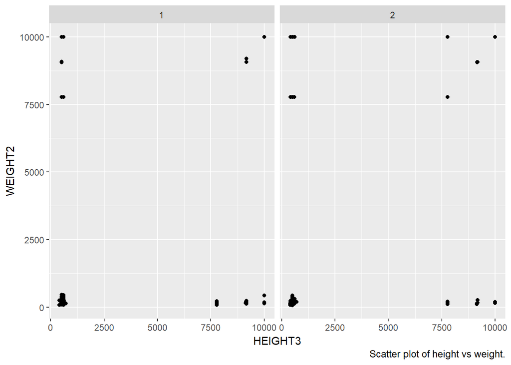

```r
caption<-paste(strwrap("Scatter plot of height vs weight.", width = 95), collapse = "\n")
ggplot(data=iowa,aes(x=HEIGHT3,y=WEIGHT2))+geom_point()+labs(caption = caption)+facet_wrap(~SEX)
```

I expected height and weight to vary linearly with each other. The plot obtained show height and weight don’t vary linearly. There are points with very high weights and very small height and points with very low weights and very large heights. This trend is visible in both sexes 1 and 2.

5. Temporarily restrict weight and height to below 2500, then plot the values again. Describe the plot you see.

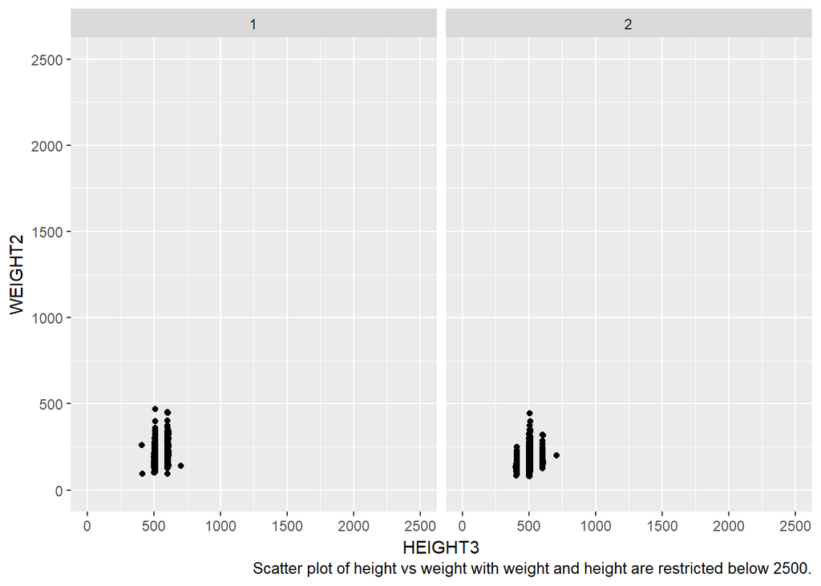

```r
caption<-paste(strwrap("Scatter plot of height vs weight with weight and height are restricted below 2500.", width = 95), collapse = "\n")
#limit x and y to be less than 2500
ggplot(data=iowa,aes(x=HEIGHT3,y=WEIGHT2))+geom_point()+facet_wrap(~SEX)+labs(caption = caption)+xlim(0, 2500)+ylim(0, 2500)
```

The plot shows that variance in height is less as compared to the variance in weight. There is still no linear relationship between the two variables.

It turns out, that the following coding scheme is used for HEIGHT3:

| HEIGHT3 value | Interpretation |
| --- | --- |
| 200 - 711 | Height (ft/inches), i.e. 410 is 4 feet, 10 inches |
| 7777 | Don’t know/Not sure |
| 9000 - 9998 | Height (meters/centimeters), where the first 9 indicates that the measurement was metric, 9165 is 1 meter 65 cm |
| 9999 | Refused |
| BLANK | Not asked or Missing |

The overall goal is to introduce a new variable `height` that corresponds to reported height in centimeters [cm].

6. Introduce a variable `feet` into the data set `iowa` that contains the hundreds and thousands of the `HEIGHT3` variable. Replace values of 77 and above in `feet` by missing value symbol `NA`. How many missing values does the variable `feet` have at this point? Think of the integer division `%/%`.

```r
iowa$feet[which(iowa$HEIGHT3<=711)]<-iowa$HEIGHT3[which(iowa$HEIGHT3<=711)]%/%100

#how many NA in feet
nas<-length(which(is.na(iowa$feet)))
```

[output not shown]

7. Introduce a variable `inch` into the data set `iowa` that consists of the last two digits in the variable `HEIGHT3`. Replace all values that are missing in the `feet` variable by missing values in the variable `inch`. Think of the modulo operator `%%`.

```r
iowa$inch[which(iowa$HEIGHT3<=711)]<-iowa$HEIGHT3[which(iowa$HEIGHT3<=711)]%%100
```

8. Introduce a variable `height` in the iowa data that is a conversion of the height values in feet and inch to meters. For your convenience: 1 ft equals 30.48 cm, 1 inch equals 2.54 cm. 1 m equals 100 cm.

```r
iowa$height<-(iowa$feet*30.48+iowa$inch*2.54)/100
```

9. Plot a histogram of `height`, facet by gender such that the histograms are on top of each other. Comment on the resulting plot.

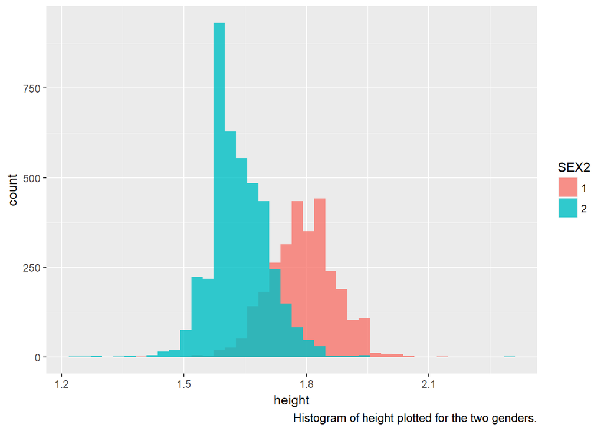

```r
#introduce SEX variable as a factor
iowa$SEX2<-as.factor(iowa$SEX)
caption<-paste(strwrap("Histogram of height plotted for the two genders.", width = 95), collapse = "\n")
ggplot(data=iowa,aes(x=height,fill=SEX2)) + geom_histogram(alpha = 0.8,bins = 40,position ='identity')+labs(caption = caption)
```

The above figure shows the histogram of height for the two genders. We can see that the mean height of gender 2 is less than that of gender 1. Variance in heights of gender 1 seems to be higher than that of gender 2.